# Assignment 4

Muhammad Bilal Aitmad

2026-10-26

Loading packages

```r
library(readr)
library(tidyverse)
```

Loading data

```r
setwd("~/Desktop/KSU/Sem 1/Machine Learning/ass 4")
```

```r
getwd()
```

```
## [1] "/Users/muhammadbilalaitmad/Desktop/KSU/Sem 1/Machine Learning/ass 4"
```

```r
pharma <- read_csv("pharmaceuticals.csv")
str(pharma)
```

```
## spc_tbl_ [21 × 14] (S3: spec_tbl_df/tbl_df/tbl/data.frame)
##  $ Symbol               : chr [1:21] "ABT" "AGN" "AHM" "AZN" ...
##  $ Name                 : chr [1:21] "Abbott Laboratories" "Allergan, Inc." "Amersham plc" "AstraZeneca PLC" ...
##  $ Market_Cap           : num [1:21] 68.44 7.58 6.3 67.63 47.16 ...
##  $ Beta                 : num [1:21] 0.32 0.41 0.46 0.52 0.32 1.11 0.5 0.85 1.08 0.18 ...
##  $ PE_Ratio             : num [1:21] 24.7 82.5 20.7 21.5 20.1 27.9 13.9 26 3.6 27.9 ...
##  $ ROE                  : num [1:21] 26.4 12.9 14.9 27.4 21.8 3.9 34.8 24.1 15.1 31 ...
##  $ ROA                  : num [1:21] 11.8 5.5 7.8 15.4 7.5 1.4 15.1 4.3 5.1 13.5 ...
##  $ Asset_Turnover       : num [1:21] 0.7 0.9 0.9 0.9 0.6 0.6 0.9 0.6 0.3 0.6 ...
##  $ Leverage             : num [1:21] 0.42 0.6 0.27 0 0.34 0 0.57 3.51 1.07 0.53 ...
##  $ Rev_Growth           : num [1:21] 7.54 9.16 7.05 15 26.81 ...
##  $ Net_Profit_Margin    : num [1:21] 16.1 5.5 11.2 18 12.9 2.6 20.6 7.5 13.3 23.4 ...
##  $ Median_Recommendation: chr [1:21] "Moderate Buy" "Moderate Buy" "Strong Buy" "Moderate Sell" ...
##  $ Location             : chr [1:21] "US" "CANADA" "UK" "UK" ...
##  $ Exchange             : chr [1:21] "NYSE" "NYSE" "NYSE" "NYSE" ...
##  - attr(*, "spec")=
##   .. cols(
##   ..   Symbol = col_character(),
##   ..   Name = col_character(),
##   ..   Market_Cap = col_double(),
##   ..   Beta = col_double(),
##   ..   PE_Ratio = col_double(),
##   ..   ROE = col_double(),
##   ..   ROA = col_double(),
##   ..   Asset_Turnover = col_double(),
##   ..   Leverage = col_double(),
##   ..   Rev_Growth = col_double(),
##   ..   Net_Profit_Margin = col_double(),
##   ..   Median_Recommendation = col_character(),
##   ..   Location = col_character(),
##   ..   Exchange = col_character()
##   .. )
##  - attr(*, "problems")=<externalptr>
```

```r
summary(pharma)
```

```
##     Symbol              Name             Market_Cap          Beta
##  Length:21          Length:21          Min.   :  0.41   Min.   :0.1800
##  Class :character   Class :character   1st Qu.:  6.30   1st Qu.:0.3500
##  Mode  :character   Mode  :character   Median : 48.19   Median :0.4600
##                                        Mean   : 57.65   Mean   :0.5257
##                                        3rd Qu.: 73.84   3rd Qu.:0.6500
##                                        Max.   :199.47   Max.   :1.1100
##     PE_Ratio          ROE            ROA        Asset_Turnover    Leverage
##  Min.   : 3.60   Min.   : 3.9   Min.   : 1.40   Min.   :0.3    Min.   :0.0000
##  1st Qu.:18.90   1st Qu.:14.9   1st Qu.: 5.70   1st Qu.:0.6    1st Qu.:0.1600
##  Median :21.50   Median :22.6   Median :11.20   Median :0.6    Median :0.3400
##  Mean   :25.46   Mean   :25.8   Mean   :10.51   Mean   :0.7    Mean   :0.5857
##  3rd Qu.:27.90   3rd Qu.:31.0   3rd Qu.:15.00   3rd Qu.:0.9    3rd Qu.:0.6000
##  Max.   :82.50   Max.   :62.9   Max.   :20.30   Max.   :1.1    Max.   :3.5100
##    Rev_Growth    Net_Profit_Margin Median_Recommendation   Location
##  Min.   :-3.17   Min.   : 2.6      Length:21             Length:21
##  1st Qu.: 6.38   1st Qu.:11.2      Class :character      Class :character
##  Median : 9.37   Median :16.1      Mode  :character      Mode  :character
##  Mean   :13.37   Mean   :15.7
##  3rd Qu.:21.87   3rd Qu.:21.1
##  Max.   :34.21   Max.   :25.5
##    Exchange
##  Length:21
##  Class :character
##  Mode  :character
##
##
##
```

Normalizing numerical variables

```r
num.vars <- pharma[, c(
  "Market_Cap",
  "Beta",
  "PE_Ratio",
  "ROE",
  "ROA",
  "Asset_Turnover",
  "Leverage",
  "Rev_Growth",
  "Net_Profit_Margin"
)]

num.scaled <- scale(num.vars)
```

```r
library(cluster)
sil.width <- numeric()

for(k in 2:6)
{
  km <- kmeans(num.scaled,
               centers = k,
               nstart = 25)

  sil <- silhouette(km$cluster,
                    dist(num.scaled))

  sil.width[k] <- mean(sil[,3])
}

sil.width[2:6]
```

```
## [1] 0.2732188 0.2797581 0.2245206 0.2492917 0.2500291
```

Elbow plot

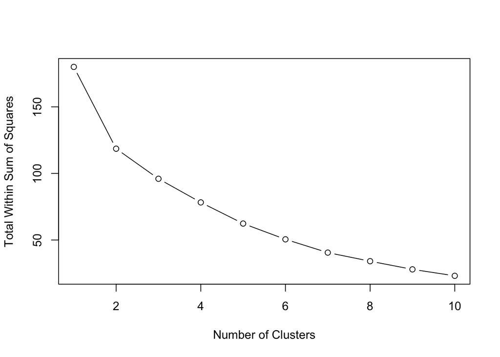

```r
wss <- numeric()

for(k in 1:10)
{
  wss[k] <- kmeans(num.scaled,
                   centers = k,
                   nstart = 25)$tot.withinss
}

plot(1:10,
     wss,
     type = "b",
     xlab = "Number of Clusters",
     ylab = "Total Within Sum of Squares")
```

```r
set.seed(123)

km3 <- kmeans(num.scaled,
              centers = 3,
              nstart = 25)

km3
```

```
## K-means clustering with 3 clusters of sizes 4, 11, 6
##
## Cluster means:
##   Market_Cap       Beta   PE_Ratio        ROE        ROA Asset_Turnover
## 1 -0.6125361  0.2698666  1.3143935 -0.9609057 -1.0174553      0.2306328
## 2  0.6733825 -0.3586419 -0.2763512  0.6565978  0.8344159      0.4612656
## 3 -0.8261772  0.4775991 -0.3696184 -0.5631589 -0.8514589     -0.9994088
##     Leverage Rev_Growth Net_Profit_Margin
## 1 -0.3592866 -0.5757385        -1.3784169
## 2 -0.3331068 -0.2902163         0.6823310
## 3  0.8502201  0.9158889        -0.3319956
##
## Clustering vector:
##  [1] 2 1 1 2 3 1 2 3 3 2 2 3 2 3 2 2 2 1 2 3 2
##
## Within cluster sum of squares by cluster:
## [1] 20.54199 43.30886 32.14336
##  (between_SS / total_SS =  46.7 %)
##
## Available components:
##
## [1] "cluster"      "centers"      "totss"        "withinss"     "tot.withinss"
## [6] "betweenss"    "size"         "iter"         "ifault"
```

```r
pharma$Cluster <- factor(km3$cluster)

pharma[, c("Name", "Cluster")]
```

```
## # A tibble: 21 × 2
##    Name                         Cluster
##    <chr>                        <fct>
##  1 Abbott Laboratories          2
##  2 Allergan, Inc.               1
##  3 Amersham plc                 1
##  4 AstraZeneca PLC              2
##  5 Aventis                      3
##  6 Bayer AG                     1
##  7 Bristol-Myers Squibb Company 2
##  8 Chattem, Inc                 3
##  9 Elan Corporation, plc        3
## 10 Eli Lilly and Company        2
## # ℹ 11 more rows
```

```r
table(pharma$Cluster)
```

```
##
##  1  2  3
##  4 11  6
```

Cluster Centroids

```r
round(km3$centers, 2)
```

```
##   Market_Cap  Beta PE_Ratio   ROE   ROA Asset_Turnover Leverage Rev_Growth
## 1      -0.61  0.27     1.31 -0.96 -1.02           0.23    -0.36      -0.58
## 2       0.67 -0.36    -0.28  0.66  0.83           0.46    -0.33      -0.29
## 3      -0.83  0.48    -0.37 -0.56 -0.85          -1.00     0.85       0.92
##   Net_Profit_Margin
## 1             -1.38
## 2              0.68
## 3             -0.33
```

Cluster means in original units

```r
aggregate(num.vars,
          by = list(Cluster = pharma$Cluster),
          mean)
```

```
##   Cluster Market_Cap      Beta PE_Ratio  ROE       ROA Asset_Turnover  Leverage
## 1       1   21.75500 0.5950000 46.90000 11.3  5.100000      0.7500000 0.3050000
## 2       2   97.11364 0.4336364 20.95455 35.7 14.954545      0.8000000 0.3254545
## 3       3    9.23500 0.6483333 19.43333 17.3  5.983333      0.4833333 1.2500000
##   Rev_Growth Net_Profit_Margin
## 1    7.01000           6.65000
## 2   10.16455          20.17273
## 3   23.49000          13.51667
```

Part B: Interpretation of the clusters

```r
cluster.summary <- aggregate(
  num.vars,
  by = list(Cluster = pharma$Cluster),
  mean)

cluster.summary[,-1] <- round(cluster.summary[,-1], 2)

cluster.summary
```

```
##   Cluster Market_Cap Beta PE_Ratio  ROE   ROA Asset_Turnover Leverage
## 1       1      21.75 0.60    46.90 11.3  5.10           0.75     0.30
## 2       2      97.11 0.43    20.95 35.7 14.95           0.80     0.33
## 3       3       9.23 0.65    19.43 17.3  5.98           0.48     1.25
##   Rev_Growth Net_Profit_Margin
## 1       7.01              6.65
## 2      10.16             20.17
## 3      23.49             13.52
```

Interpretation

Cluster 1: Speculative High Valuation Pharma firms

Average Market Cap = $21.75 billion Highest P/E Ratio = 46.9 Lowest ROE = 11.3% Lowest ROA = 5.1% Lowest Net Profit Margin = 6.65% Lowest Revenue Growth = 7.01%

This cluster contains firms that are not producing particularly strong profitability results but are valued highly by investors, as indicated by the extremely high average P/E ratio.

Cluster 2: Global Pharma Leaders

Average Market Cap = $97.11 billion Highest ROE = 35.7% Highest ROA = 14.95% Highest Net Profit Margin = 20.17% Low leverage = 0.33 Relatively low beta = 0.43

Evident by existence of global leaders like Pfizer, this cluster contains the industry’s largest and most established firms. These companies demonstrate superior profitability, efficient use of assets, strong shareholder returns.

Cluster 3: Emerging Growth Firms

Smallest Market Cap = $9.24 billion Highest Revenue Growth = 23.49% Highest Leverage = 1.25 Higher Beta = 0.65

These firms are much smaller than the industry leaders but demonstrate significantly stronger growth rates. Their higher leverage and beta indicate greater risk, while their rapid revenue growth suggests an aggressive expansion strategy.

Part C:

Median Recommendation vs clusters

```r
table(pharma$Cluster,
      pharma$Median_Recommendation)
```

```
##
##     Hold Moderate Buy Moderate Sell Strong Buy
##   1    2            1             0          1
##   2    6            3             2          0
##   3    1            3             2          0
```

```r
round(
  prop.table(
    table(pharma$Cluster,
          pharma$Median_Recommendation),
    margin = 1
  ),
  2
)
```

```
##
##     Hold Moderate Buy Moderate Sell Strong Buy
##   1 0.50         0.25          0.00       0.25
##   2 0.55         0.27          0.18       0.00
##   3 0.17         0.50          0.33       0.00
```

```r
table(pharma$Cluster,
      pharma$Location)
```

```
##
##     CANADA FRANCE GERMANY IRELAND SWITZERLAND UK US
##   1      1      0       1       0           0  1  1
##   2      0      0       0       0           1  2  8
##   3      0      1       0       1           0  0  4
```

```r
round(
  prop.table(
    table(pharma$Cluster,
          pharma$Location),
    margin = 1
  ),
  2
)
```

```
##
##     CANADA FRANCE GERMANY IRELAND SWITZERLAND   UK   US
##   1   0.25   0.00    0.25    0.00        0.00 0.25 0.25
##   2   0.00   0.00    0.00    0.00        0.09 0.18 0.73
##   3   0.00   0.17    0.00    0.17        0.00 0.00 0.67
```

```r
table(pharma$Cluster,
      pharma$Exchange)
```

```
##
##     AMEX NASDAQ NYSE
##   1    0      0    4
##   2    0      0   11
##   3    1      1    4
```

```r
round(
  prop.table(
    table(pharma$Cluster,
          pharma$Exchange),
    margin = 1
  ),
  2
)
```

```
##
##     AMEX NASDAQ NYSE
##   1 0.00   0.00 1.00
##   2 0.00   0.00 1.00
##   3 0.17   0.17 0.67
```

Cluster 2 seems to be dominated by US, UK, and Switzerland. This means headquartered in strong economic zones. Cluster 1 is diversely spread. Cluster 3 seems to be usually headquartered in the US mostly as well which indicates strong funding for emerging firms with a high upside.

Almost every company across all clusters is listed on the NYSE. Because nearly all firms share the same exchange listing, exchange does not appear to be a meaningful variable for distinguishing clusters.

Part D:

Cluster 1 was labeled Speculative High Valuation Firms because it contains companies with high P/E ratios but relatively weak profitability. Cluster 2 was labeled Global Pharmaceutical Leaders because it includes the largest, most profitable, and most financially stable firms in the industry. Cluster 3 was labeled Emerging Growth Firms because it consists of smaller companies with high revenue growth and higher leverage levels, indicating an emphasis on expansion and future growth.